# Honesty at the Margin

12/17/2017

## Context with my work & work by co-authors

- Paper on principal-agent relationships & benefits of abstaining from control accepted at J. Economic Behavior and Organization.
- Related to this idea of P-A relationships, is a paper I have with a Jonathan Lafky on rating systems (being revised after rejection)
- Jonathan has a related paper with Alistair on incentives for information transmission

## Context

Evidence in experimental and behavioral economics suggests the following:

- people have a *preference* for honesty (or against guilty or lying)
  - see Gneezy (2005), Gneezy et al (2013), Dreber & Johannssen (2010), Kartik (2009), and many others
- people have a utility function with standard properties
  - they have *social preferences* because they *dislike* lying
  - lying imposes a utility cost
  - extensive margin: a cost to lying at all
  - intensive margin: a cost in *size* of lie

## Lying in the real world?

But there's lots of evidence of people lying for profit

- people lied about MBS and CDOs prior to the financial crisis
- financial advisers who are *not* fiduciaries
- medical professionals who benefit from prescribing certain drugs
- lawyers displaying prosecutorial dishonesty

## Motivating questions & gaps in literature

- If lies are preference-based, how vulnerable are the preferences to institutional setting?
  - Do the preferences override the setting, or are the preferences context-dependent?
- How do people respond to the opportunity to lie when competing with others?
- Can competition encourage/discourage full deception rather than merely 'disguised' lies (Fischbacher and Föllmi-Heusi, 2013)?
- How does the size of outside offers affect choices to compete & lie?
- Do people select into honest settings knowing others will lie?
- Do people adapt to deception and lie more? (Garrett et al, 2016)

## Design Context

Fischbacher and Föllmi-Heushi (JEEA, 2013)

- a dice-throwing game to measure *aggregate* deception.
- subjects roll a 6-sided die and report what they rolled
- Roll of 6 \(\Rightarrow\) CHF 0,
- Roll of \(1 \rightarrow 5 \Rightarrow\) equivalent CHF
- with large \(n\), should be a uniform distribution \(U \sim [0, 5]\)

## For example…

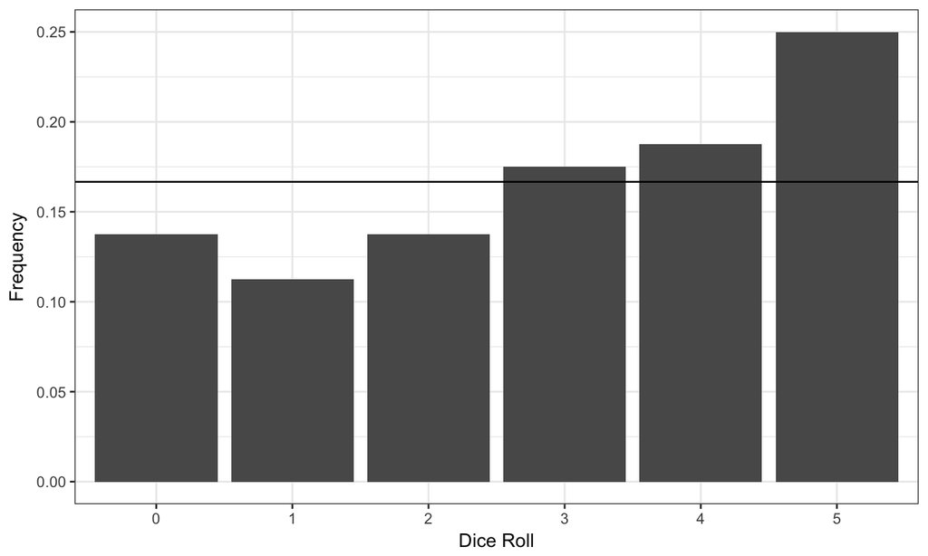

[interactive chart not shown]

## FFH's Results

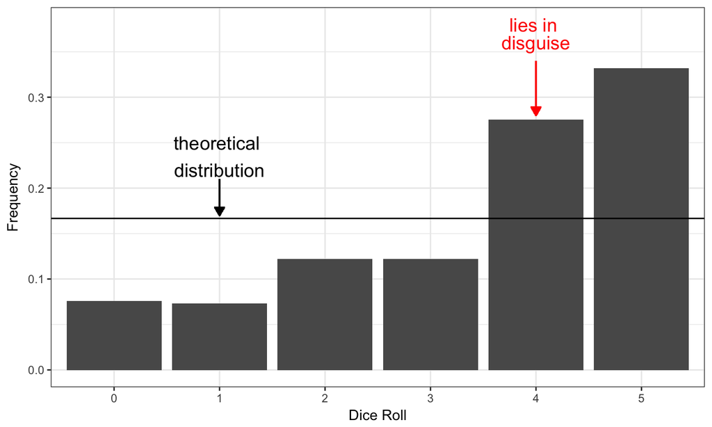

## FFH Continued

- also did a ‘high-stakes’ treatment
  - subjects were paid CHF3 per pip reported up to CHF15
- choices all one-shot and the majority of the analysis is between subjects.
- Because the experiment was run after other experiments (as a 10-minute add-on), some subjects participated more than once.
- Subjects who participated more than once were more likely to report a higher number the second time.

## Extension: D & K (2017)

Dannenberg and Khachatryan (2017, working paper)

- replicate FFH + competition + group decisoins
- one-shot competitive choice either with one other participant, as a member of a team of three against another team of three, or as a single or team of three against a single or team of three (2 by 2 treatment design). The authors provide evidence suggesting that subjects who compete one-on-one are no more dishonest than subjects who do not compete when making their choices. On the contrary, teams of three against teams of three are more likely to report higher numbers (are more dishonest).

## Gaps left by FFH, D & K?

- Subjects in a "competitive" treatment have no choice about competing
- Group vs. individual not that interesting to us
- If a subject cannot choose *not* to compete, is it really a *choice to compete*?
- What is the role of an outside offer/opportunity cost?
- What about the margins of:
  - choosing to compete and
  - reports of those who compete conditional on having chosen to compete?

## Our design (HLW)

T1: Baseline Treatment (Decision problem)

- Choice of two options, A or B.
- If A is chosen, subject reports a 10-sided die roll, which is compared to three random numbers generated by a bingo cage (automated).
  - If the report matches any selected number, they receive $20.
  - Otherwise payment is $0.00.
- If B is chosen, the subject reports a 10-sided die roll.
  - Roll compared with a publicly rolled 10-side die.
  - If higher, player obtains $20; 50-50 chance on a tie.

## Our design (HLW, contd.)

T2: Treament "Automated High Roll" (Decision problem)

- Same as T1, except zero probability of winning if report is 0 through 8
- 50-50 chance of prize if reporting 9.
- Why? Upper-bound limit on those who want the 50-50 lottery if they are guaranteed to lie.

## Our design (HLW, contd.)

T3: Competition (Strategic)

- Each session has four (?) groups of 6 (?) subjects
- Choice of two options, A or B.
- If A is chosen, subject reports a 10-sided die roll, which is compared to three random numbers generated by a bingo cage (automated).
  - If the report matches any selected number, they receive $20.
  - Otherwise payment is $0.00.
- If B is chosen, the subject reports a 10-sided die roll.
  - Roll compared with a another player's reported 10-side die roll.
  - If higher, player obtains $20; 50-50 chance on a tie.

## Our design (HLW, contd.)

Additional details

- Subject repeats their choice 24/25 times.
- We observe the margin of choosing Options A or B (extensive)
- On choosing B, we measure the distribution of reports (intensive because repeated within subject)
- Contrast with theoretical distribution and across treatments

## Potential behaviors (randomized n = 100 rolls)

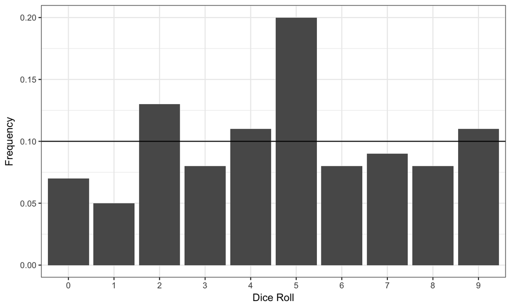

[interactive chart not shown]

## Conclusions and contributions?

- Measure margins not previously measured
- Choices are repeated, so no concern that subjects don't know what they're doing (others so far are one-shot).
- Task is relatively short with a high expected payoff for the short task (incentive compatible)
- We're still decided on how many of the 24/25 choices to pay (2 or 3?)
- Extensions
  - experiment to examine demand and supply of deception
  - what happens if hiring decisions are based on report? \(\uparrow\) or \(\downarrow\) deception?